# Stereo Matching with Loopy Belief Propagation

**TRIVA**

## Question 1 — Formules LBP (théorie)

### i) Formule générale des messages

À l'itération $t$, le message que le nœud $p$ envoie au voisin $q$ pour le label $l_q$ est :

$$m^t_{p \to q}(l_q) = \min_{l_p} \left[ D_p(l_p) + V(l_p - l_q) + \sum_{r \in N(p) \setminus q} m^{t-1}_{r \to p}(l_p) \right]$$

où :

- $D_p(l_p)$ est le coût de données du pixel $p$ pour le label $l_p$
- $V(l_p - l_q)$ est le coût pairwise entre labels voisins
- La somme porte sur tous les voisins de $p$ **sauf** $q$ (messages entrants)

### ii) Complexité générale

Pour calculer le vecteur complet $m^t_{p \to q}$ (de taille $d_{max}$) :

- Pour chaque label $l_q$ : on minimise sur $d_{max}$ valeurs de $l_p$
- **Complexité : $O(d_{max}^2)$ par arête**, soit $O(4 \cdot |P| \cdot d_{max}^2)$ pour toute l'image.

### iii) Beliefs et labels MAP

Les beliefs du nœud $q$ à l'itération $t$ :

$$b^t_q(l_q) = D_q(l_q) + \sum_{r \in N(q)} m^t_{r \to q}(l_q)$$

Le label MAP du pixel $q$ est :

$$l^*_q = \arg\min_{l_q} b^t_q(l_q)$$

## Question 2 — Formule efficace avec le modèle de Potts

Le modèle de Potts : $V(x) = 0$ si $x=0$, $1$ sinon.

Posons $h_p(l_p) = D_p(l_p) + \sum_{r \in N(p) \setminus q} m^{t-1}_{r \to p}(l_p)$ (coût local agrégé).

Le message s'écrit :

$$m^t_{p \to q}(l_q) = \min\left( h_p(l_q),\ \min_{l_p \neq l_q} h_p(l_p) + 1 \right) = \min\left( h_p(l_q),\ \min_{l_p} h_p(l_p) + 1 \right)$$

Car si $l_p \neq l_q$ : $V = 1$, si $l_p = l_q$ : $V = 0$.

Donc : $$\boxed{m^t_{p \to q}(l_q) = \min\left( h_p(l_q),\ \min_{l_p} h_p(l_p) + 1 \right)}$$

On calcule $\min_{l_p} h_p(l_p)$ **une seule fois** (scalaire), puis on applique la formule vectoriellement.

**Complexité : $O(d_{max})$ par arête** au lieu de $O(d_{max}^2)$, gain considérable !

## Question 3 — Implémentation

```python
import numpy as np
import scipy.ndimage
import imageio.v2 as imageio
import matplotlib.pyplot as plt
```

```python
def compute_data_cost(I1, I2, num_disp_values, Tau):
    """
    Calcule le coût de données : un tableau 3D de taille hauteur x
    largeur x num_disp_values.
    data_cost(y, x, l) = min(1/3 * ||I1[y,x] - I2[y,x-l]||_1, Tau)
    """
    h, w, _ = I1.shape
    dataCost = np.zeros((h, w, num_disp_values))

    for l in range(num_disp_values):
        # Décale I2 vers la droite de l pixels
        I2_shifted = np.zeros_like(I2)
        if l == 0:
            I2_shifted = I2
        else:
            I2_shifted[:, l:, :] = I2[:, :-l, :]  # x-l dans I2
            #correspond au décalage
            # Les pixels où x-l < 0 restent à 0 (bord gauche)

        # Norme L1 sur les canaux de couleur, divisée par 3
        diff = np.sum(np.abs(I1 - I2_shifted), axis=2) / 3.0

        # Troncature à Tau
        dataCost[:, :, l] = np.minimum(diff, Tau)
        # Pixels hors-image (x-l < 0) : coût = Tau
        if l > 0:
            dataCost[:, :l, l] = Tau

    return dataCost
```

```python
def compute_energy(dataCost, disparity, Lambda):
    """
    Calcule l'énergie totale E(L) = sum_p D_p(l_p) +
    Lambda * sum_{p,q in N} V(l_p - l_q)
    """
    h, w = disparity.shape
    disparity = disparity.astype(int)

    # Terme de données : récupère le coût à la disparité
    # assignée pour chaque pixel
    data_term = np.sum(dataCost[np.arange(h)[:, None], np.arange(w)[None, :], disparity])

    # Terme de lissage (Potts) : pénalise les pixels voisins
    # ayant des labels différents
    # Voisins horizontaux
    horiz = np.sum(disparity[:, :-1] != disparity[:, 1:])
    # Voisins verticaux
    vert = np.sum(disparity[:-1, :] != disparity[1:, :])

    smooth_term = Lambda * (horiz + vert)

    return data_term + smooth_term
```

```python
def update_msg(msgUPrev, msgDPrev, msgLPrev, msgRPrev, dataCost, Lambda):
    """
    Met à jour les messages en utilisant la formule efficace
    du modèle de Potts.

    Convention :
      msgU[y,x,l] = message envoyé DU pixel (y,x) AU pixel (y-1,x)
      [vers le haut]
      msgD[y,x,l] = message envoyé DU pixel (y,x) AU pixel (y+1,x)
      [vers le bas]
      msgL[y,x,l] = message envoyé DU pixel (y,x) AU pixel (y,x-1)
      [vers la gauche]
      msgR[y,x,l] = message envoyé DU pixel (y,x) AU pixel (y,x+1)
      [vers la droite]
    """
    #on décale les tableaux pour aligner les messages précédents
    # sur nos pixels actuels
    #de cette façon chaque pixel reçoit ses 4 messages précédents
    #on part du coin en haut à gauche donc quand on descend on augmente y
    msg_from_up    = np.roll(msgDPrev,  1, axis=0); msg_from_up[0, :, :]    = 0
    msg_from_down  = np.roll(msgUPrev, -1, axis=0); msg_from_down[-1, :, :] = 0
    msg_from_left  = np.roll(msgRPrev,  1, axis=1); msg_from_left[:, 0, :]  = 0
    msg_from_right = np.roll(msgLPrev, -1, axis=1); msg_from_right[:, -1, :] = 0

    # Message vers le HAUT : de (y,x) vers (y-1,x)
    # Messages entrants de tous les voisins sauf la cible (y-1,x),
    # i.e., depuis bas, gauche, droite
    # h_p(l) = coût de données + msg du bas + msg de gauche + msg
    # de droite
    h_up = dataCost + msg_from_down + msg_from_left + msg_from_right
    min_h_up = np.min(h_up, axis=2, keepdims=True)
    msgU = np.minimum(h_up, min_h_up + Lambda)
    # Bord : les pixels de la première ligne ne peuvent pas envoyer
    # vers le haut
    msgU[0, :, :] = 0

    # Message vers le BAS : de (y,x) vers (y+1,x)
    # Messages entrants depuis haut, gauche, droite (on exclut le
    # voisin du bas)
    h_down = dataCost + msg_from_up + msg_from_left + msg_from_right
    min_h_down = np.min(h_down, axis=2, keepdims=True)
    msgD = np.minimum(h_down, min_h_down + Lambda)
    # Bord : les pixels de la dernière ligne ne peuvent pas envoyer
    #  vers le bas
    msgD[-1, :, :] = 0

    # Message vers la GAUCHE : de (y,x) vers (y,x-1)
    # Messages entrants depuis haut, bas, droite (on exclut le voisin
    #  de gauche)
    h_left = dataCost + msg_from_up + msg_from_down + msg_from_right
    min_h_left = np.min(h_left, axis=2, keepdims=True)
    msgL = np.minimum(h_left, min_h_left + Lambda)
    # Bord : les pixels de la première colonne ne peuvent pas envoyer
    #  vers la gauche
    msgL[:, 0, :] = 0

    # Message vers la DROITE : de (y,x) vers (y,x+1)
    # Messages entrants depuis haut, bas, gauche (on exclut le voisin
    # de droite)
    h_right = dataCost + msg_from_up + msg_from_down + msg_from_left
    min_h_right = np.min(h_right, axis=2, keepdims=True)
    msgR = np.minimum(h_right, min_h_right + Lambda)
    # Bord : les pixels de la dernière colonne ne peuvent pas envoyer
    # vers la droite
    msgR[:, -1, :] = 0

    return msgU, msgD, msgL, msgR
```

```python
def normalize_msg(msgU, msgD, msgL, msgR):
    """Soustrait la moyenne le long de la dimension de
    profondeur de chaque message"""
    avg = np.mean(msgU, axis=2)
    msgU -= avg[:, :, np.newaxis]
    avg = np.mean(msgD, axis=2)
    msgD -= avg[:, :, np.newaxis]
    avg = np.mean(msgL, axis=2)
    msgL -= avg[:, :, np.newaxis]
    avg = np.mean(msgR, axis=2)
    msgR -= avg[:, :, np.newaxis]
    return msgU, msgD, msgL, msgR
```

```python
def compute_belief(dataCost, msgU, msgD, msgL, msgR):
    """
    Calcule les beliefs = coût de données + somme de tous
    les messages entrants.
    b_q(l) = D_q(l) + msgU_q(l) + msgD_q(l) + msgL_q(l) + msgR_q(l)

    Convention sur les messages :
      - Le message reçu en (y,x) depuis le HAUT  est msgD[y-1,x]
      (le voisin du haut envoie vers le bas)
      - Le message reçu en (y,x) depuis le BAS   est msgU[y+1,x]
      (le voisin du bas envoie vers le haut)
      - Le message reçu en (y,x) depuis la GAUCHE est msgR[y,x-1]
      (le voisin de gauche envoie vers la droite)
      - Le message reçu en (y,x) depuis la DROITE est msgL[y,x+1]
      (le voisin de droite envoie vers la gauche)
    """
    h, w, num_labels = dataCost.shape
    beliefs = dataCost.copy()

    # Message reçu depuis le haut : msgD[y-1, x]
    beliefs[1:, :, :] += msgD[:-1, :, :]
    # Message reçu depuis le bas : msgU[y+1, x]
    beliefs[:-1, :, :] += msgU[1:, :, :]
    # Message reçu depuis la gauche : msgR[y, x-1]
    beliefs[:, 1:, :] += msgR[:, :-1, :]
    # Message reçu depuis la droite : msgL[y, x+1]
    beliefs[:, :-1, :] += msgL[:, 1:, :]

    return beliefs
```

```python
def MAP_labeling(beliefs):
    """Retourne un tableau 2D : pour chaque pixel, le label
    ayant le belief minimal"""
    return np.argmin(beliefs, axis=2)
```

```python
def stereo_bp(I1, I2, num_disp_values, Lambda, Tau=15, num_iterations=60):
    """Fonction principale de la mise en correspondance stéréo par LBP"""

    # Calcul du coût de données pour tous les pixels et toutes les disparités
    dataCost = compute_data_cost(I1, I2, num_disp_values, Tau)

    # Tableau pour stocker l'énergie à chaque itération
    energy = np.zeros(num_iterations)

    # Initialisation des messages à zéro dans les 4 directions
    h, w, _ = I1.shape
    msgU = np.zeros((h, w, num_disp_values))  # messages vers le haut
    msgD = np.zeros((h, w, num_disp_values))  # messages vers le bas
    msgL = np.zeros((h, w, num_disp_values))  # messages vers la gauche
    msgR = np.zeros((h, w, num_disp_values))  # messages vers la droite

    for iter in range(num_iterations):
        # Mise à jour des messages dans les 4 directions
        msgU, msgD, msgL, msgR = update_msg(msgU, msgD, msgL, msgR, dataCost, Lambda)
        # Normalisation des messages pour éviter la divergence numérique
        msgU, msgD, msgL, msgR = normalize_msg(msgU, msgD, msgL, msgR)
        # Calcul des beliefs à partir des messages et du coût de données
        beliefs = compute_belief(dataCost, msgU, msgD, msgL, msgR)
        # Estimation MAP : on choisit le label de disparité
        # minimisant le belief
        disparity = MAP_labeling(beliefs)
        # Calcul de l'énergie globale pour suivre la convergence
        energy[iter] = compute_energy(dataCost, disparity, Lambda)

        if (iter + 1) % 10 == 0:
            print(f"  Itération {iter+1}/{num_iterations} — Énergie : {energy[iter]:.1f}")

    return disparity, energy
```

## Chargement des images

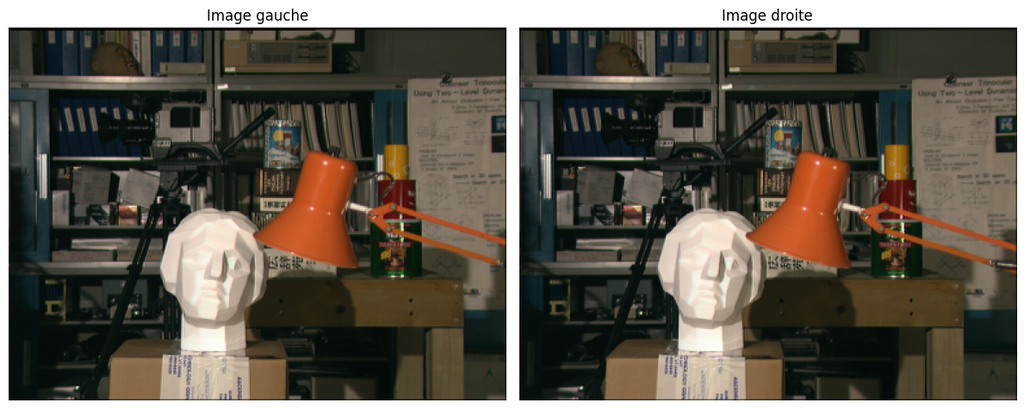

```python
img_left  = imageio.imread('tsukuba/imL.png')
img_right = imageio.imread('tsukuba/imR.png')

fig, axes = plt.subplots(1, 2, figsize=(12, 5))
axes[0].imshow(img_left);  axes[0].set_title('Image gauche'); axes[0].axis('off')
axes[1].imshow(img_right); axes[1].set_title('Image droite'); axes[1].axis('off')
plt.tight_layout()
plt.show()

# Convertit en float
img_left  = img_left.astype(float)
img_right = img_right.astype(float)

# Gaussian pre-filtering
I1 = scipy.ndimage.gaussian_filter(img_left,  sigma=(0.6, 0.6, 0))
I2 = scipy.ndimage.gaussian_filter(img_right, sigma=(0.6, 0.6, 0))

num_disp_values = 16
```

## Question 4 — Rôle de `normalize_msg`

La fonction `normalize_msg` soustrait la **moyenne sur les labels** de chaque message : $$m_{p \to q}(l) \leftarrow m_{p \to q}(l) - \frac{1}{d_{max}} \sum_{l'} m_{p \to q}(l')$$

**Rôle :** Elle empêche les messages de croître indéfiniment au fil des itérations. Sans cette normalisation, les valeurs des messages peuvent diverger.

**Impact sur les labels MAP ?** Théoriquement non. Soustraire une constante (la moyenne) à tous les labels d'un message ne change pas le $\arg\min$ des beliefs, car les beliefs sont une somme de messages et de data costs, soustraire une constante à tous les labels d'un message déplace uniformément les beliefs, sans changer quel label est minimal.

## Question 5 — Résultats pour λ = 1, 10, 100

```python
lambdas = [1, 10, 100]
results = {}

for lam in lambdas:
    print(f"\n=== Lambda = {lam} ===")
    disparity, energy = stereo_bp(I1, I2, num_disp_values, Lambda=lam)
    results[lam] = (disparity, energy)
    disparity_vis = (disparity * (255 // (num_disp_values - 1))).astype(np.uint8)
    imageio.imwrite(f'disparity_{lam}.png', disparity_vis)
    print(f"  Saved disparity_{lam}.png")
```

```
=== Lambda = 1 ===
  Itération 10/60 — Énergie : 197445.3
  Itération 20/60 — Énergie : 196119.5
  Itération 30/60 — Énergie : 195939.8
  Itération 40/60 — Énergie : 195622.0
  Itération 50/60 — Énergie : 195474.3
  Itération 60/60 — Énergie : 195559.4
  Saved disparity_1.png

=== Lambda = 10 ===
  Itération 10/60 — Énergie : 370182.2
  Itération 20/60 — Énergie : 346877.5
  Itération 30/60 — Énergie : 343324.4
  Itération 40/60 — Énergie : 341440.0
  Itération 50/60 — Énergie : 342794.1
  Itération 60/60 — Énergie : 345269.7
  Saved disparity_10.png

=== Lambda = 100 ===
  Itération 10/60 — Énergie : 1619224.5
  Itération 20/60 — Énergie : 1382734.9
  Itération 30/60 — Énergie : 1292620.0
  Itération 40/60 — Énergie : 1321463.7
  Itération 50/60 — Énergie : 1365149.1
  Itération 60/60 — Énergie : 1415833.7
  Saved disparity_100.png
```

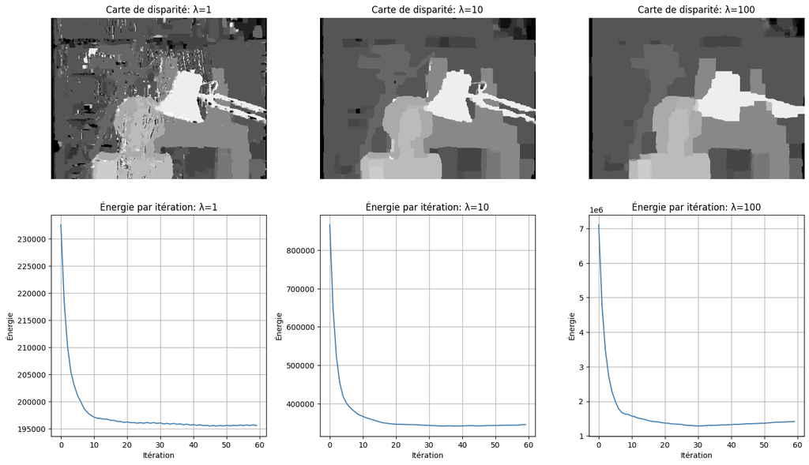

```python
fig, axes = plt.subplots(2, 3, figsize=(15, 9))

for i, lam in enumerate(lambdas):
    disparity, energy = results[lam]

    # Disparity map
    axes[0, i].imshow(disparity, cmap='gray', vmin=0, vmax=num_disp_values - 1)
    axes[0, i].set_title(f'Carte de disparité: λ={lam}')
    axes[0, i].axis('off')

    # Energy curve
    axes[1, i].plot(energy, color='steelblue')
    axes[1, i].set_title(f'Énergie par itération: λ={lam}')
    axes[1, i].set_xlabel('Itération')
    axes[1, i].set_ylabel('Énergie')
    axes[1, i].grid(True)

plt.tight_layout()
plt.savefig('results_all_lambdas.png', dpi=150)
plt.show()
```

### Analyse des résultats

**Observation sur les courbes d'énergie :**

- Pour les 3 valeurs de λ, l'énergie **descend de façon monotone** dans les premières itérations et se stabilise autour de l'itération 20-30, indiquant la convergence de l'algorithme.

**Défauts observés (même avec le meilleur λ = 10) :**

- **Zones occultées** : certains pixels visibles dans l'image gauche n'ont pas de correspondance dans l'image droite → coût de données non fiable.
- **Fond peu texturé** : l'arrière-plan est mal estimé car peu de gradient, créant des ambiguïtés de correspondance.
- **Structures fines** : le bras de la lampe est partiellement mal reconstruit.
- **LBP approximatif** : sur un graphe avec cycles (grille image), LBP n'est pas garanti de converger vers le minimum global de l'énergie, ce que confirme l'oscillation observée en fin de convergence.

```python
lambdas = [1000, 10000, 0.1]
results = {}

for lam in lambdas:
    print(f"\n=== Lambda = {lam} ===")
    disparity, energy = stereo_bp(I1, I2, num_disp_values, Lambda=lam)
    results[lam] = (disparity, energy)
    disparity_vis = (disparity * (255 // (num_disp_values - 1))).astype(np.uint8)
    imageio.imwrite(f'disparity_{lam}.png', disparity_vis)
    print(f"  Saved disparity_{lam}.png")
```

```
=== Lambda = 1000 ===
  Itération 10/60 — Énergie : 12633702.4
  Itération 20/60 — Énergie : 10686803.4
  Itération 30/60 — Énergie : 9695375.0
  Itération 40/60 — Énergie : 9271034.7
  Itération 50/60 — Énergie : 9165860.4
  Itération 60/60 — Énergie : 8592729.4
  Saved disparity_1000.png

=== Lambda = 10000 ===
  Itération 10/60 — Énergie : 124504562.9
  Itération 20/60 — Énergie : 99909700.0
  Itération 30/60 — Énergie : 92381657.9
  Itération 40/60 — Énergie : 84169022.1
  Itération 50/60 — Énergie : 76734077.2
  Itération 60/60 — Énergie : 74648387.4
  Saved disparity_10000.png

=== Lambda = 0.1 ===
  Itération 10/60 — Énergie : 149314.7
  Itération 20/60 — Énergie : 149306.7
  Itération 30/60 — Énergie : 149302.7
  Itération 40/60 — Énergie : 149301.8
  Itération 50/60 — Énergie : 149300.8
  Itération 60/60 — Énergie : 149300.7
  Saved disparity_0.1.png
```

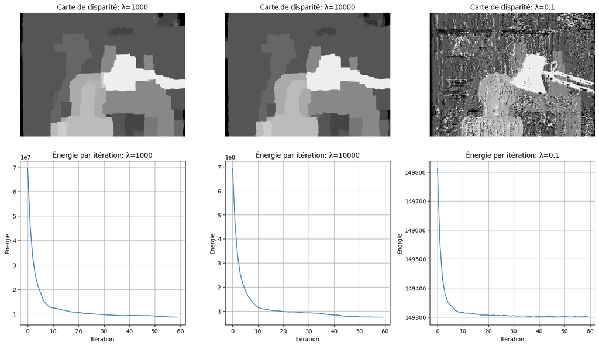

```python
fig, axes = plt.subplots(2, 3, figsize=(15, 9))

for i, lam in enumerate(lambdas):
    disparity, energy = results[lam]

    # Disparity map
    axes[0, i].imshow(disparity, cmap='gray', vmin=0, vmax=num_disp_values - 1)
    axes[0, i].set_title(f'Carte de disparité: λ={lam}')
    axes[0, i].axis('off')

    # Energy curve
    axes[1, i].plot(energy, color='steelblue')
    axes[1, i].set_title(f'Énergie par itération: λ={lam}')
    axes[1, i].set_xlabel('Itération')
    axes[1, i].set_ylabel('Énergie')
    axes[1, i].grid(True)

plt.tight_layout()
plt.savefig('results_all_lambdas.png', dpi=150)
plt.show()
```

### Résultats avec des valeurs extrêmes de λ

**λ = 0.1 (très faible) :** Le terme de données domine quasi-exclusivement. La carte est encore plus bruitée que λ=1, avec des valeurs qui semblent presque aléatoires pixel par pixel. L'énergie converge extrêmement vite (dès l'itération 5) et sur une plage très étroite (~500 unités), car le terme de lissage contribue à peine à l'énergie totale.

**λ = 1000 et λ = 10000 (très forts) :** Les deux cartes sont quasi-identiques : grandes régions uniformes très blocky, tous les détails fins ont disparu. Cela montre qu'au-delà d'un certain seuil, augmenter λ n'apporte plus rien visuellement.

Observation importante : **l'énergie ne converge pas en 60 itérations** pour ces valeurs. Pour λ=1000 elle passe de 7×10⁷ à 8.6×10⁶ en continuant de descendre, et pour λ=10000 de 7×10⁸ à 7.5×10⁷. Une régularisation très forte ralentit considérablement la convergence de LBP.

**Conclusion générale :** Ces résultats confirment que **λ = 10** est le meilleur compromis pour cette image : assez fort pour lisser le bruit, assez faible pour préserver les structures et garantir la convergence en un nombre raisonnable d'itérations.